# Albums Project 1

Maggie Ma

2024-09-23

# Top 500 Ranked Albums in 2020

### This project will be using Rolling Stone’s 2020 album rankings to determine how spotify popularity of an album is related to its Rolling Stone rank, genre, and weeks on billboard. Rolling Stone’s rankings are determined by the medium by which the album is listened with, its popularity, and voting by judges. Learn more about how Rolling Stone’s ranks are determined at https://pudding.cool/2024/03/greatest-music/.

[figure not shown]

###### From *Rolling Stone*, the definitive and beautiful companion book to one of the most popular and hotly debated lists in the music world.

# Outcome Variable

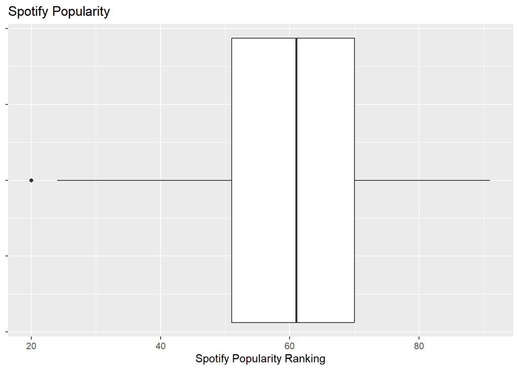

# Bivariate Analysis

### Spotify Popularity vs Rolling Stone’s Top 500 Rankings

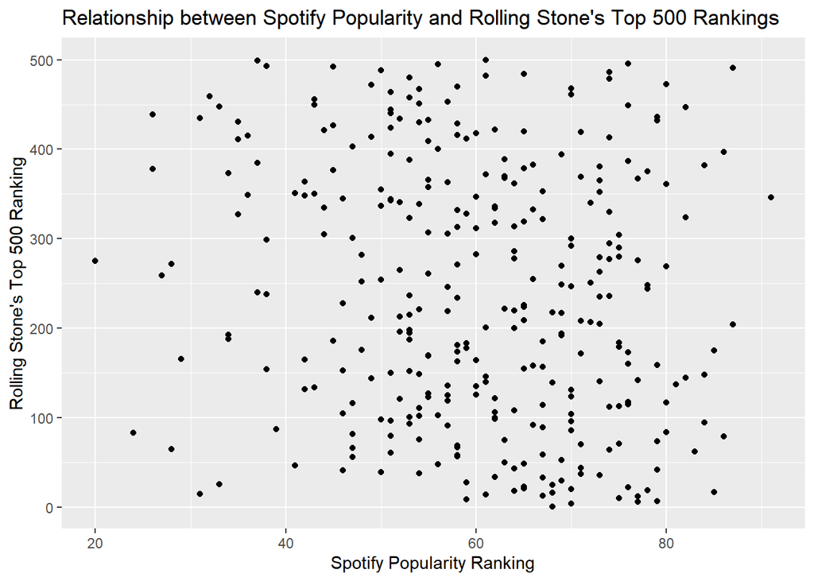

There is a very low relationship between the Spotify and Rolling Stone’s rankings. The graph seems very scattered, and there is a correlation of -0.1528879.

### Spotify Popularity by Genre

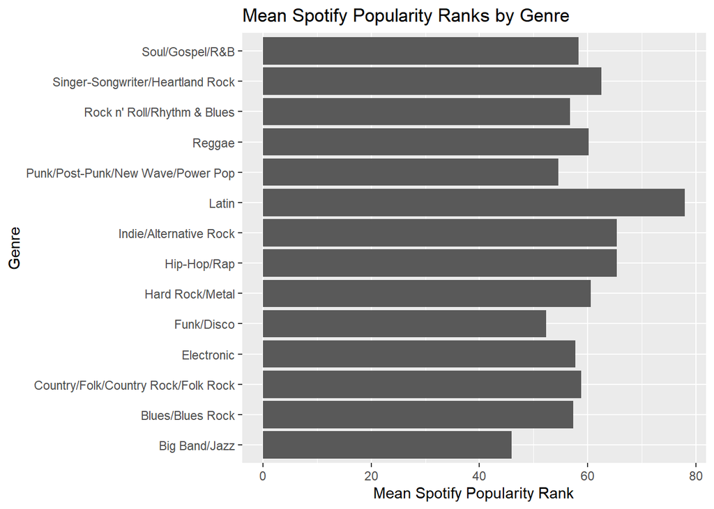